# Function Reflections

Mr. Worley

2025 Sep 3

# Generate $f(-x)$ from $f(x)$ table

Let’s define a function with a table.

| $x$ | $f(x)$ |
| --- | --- |
| -3 | 2 |
| -2 | -1 |
| -1 | 3 |
| 0 | -3 |
| 1 | -2 |
| 2 | 0 |
| 3 | 1 |

Our first goal is to make another column for $f(-x)$.

- We must distinguish between two things that were previously equivalent:
  1. The value of $x$
  2. The input into the function (the argument)
- For example, if $x=2$, then the argument of $f(-x)$ is $-2$, because $-x=-2$.
- In our example, we know $f(-2)=-1$.

  | $x$ | $f(x)$ | $f(-x)$ |
  | --- | --- | --- |
  | -3 | 2 |  |
  | -2 | -1 |  |
  | -1 | 3 |  |
  | 0 | -3 |  |
  | 1 | -2 |  |
  | 2 | 0 | -1 |
  | 3 | 1 |  |

- Can you fill the rest of the table?
- Basically, the $f(-x)$ column is just the reverse of the $f(x)$ column.

  | $x$ | $f(x)$ | $f(-x)$ |
  | --- | --- | --- |
  | -3 | 2 | 1 |
  | -2 | -1 | 0 |
  | -1 | 3 | -2 |
  | 0 | -3 | -3 |
  | 1 | -2 | 3 |
  | 2 | 0 | -1 |
  | 3 | 1 | 2 |

- Can you predict what geometric transformation relates the graphs of $y=f(x)$ and $y=f(-x)$?
- The graphs (connected with line segments for visual clarity) are reflections of each other over the $y$ axis.

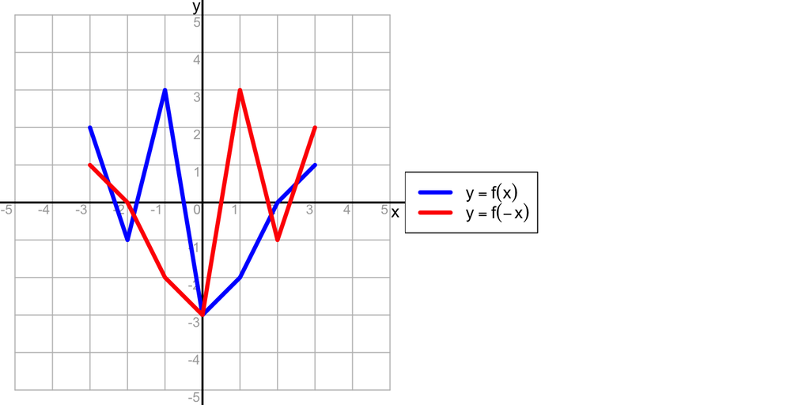

# Generate $-f(x)$ from $f(x)$ table

Let’s reuse the example function:

| $x$ | $f(x)$ |
| --- | --- |
| -3 | 2 |
| -2 | -1 |
| -1 | 3 |
| 0 | -3 |
| 1 | -2 |
| 2 | 0 |
| 3 | 1 |

Our goal is to make another column for $-f(x)$.

- Notice the value of $-f(x)$ is simply to opposite of the value of $f(x)$.
- For example, if $f(x)=3$ then $-f(x)=-3$. In our example, this means that since $f(-1)=3$ we know $-f(-1)=-3$.

  | $x$ | $f(x)$ | $-f(x)$ |
  | --- | --- | --- |
  | -3 | 2 |  |
  | -2 | -1 |  |
  | -1 | 3 | -3 |
  | 0 | -3 |  |
  | 1 | -2 |  |
  | 2 | 0 |  |
  | 3 | 1 |  |

- Can you predict the rest of the table?
- To produce this new column, we just use the negatives of the values in the $f(x)$ column.

  | $x$ | $f(x)$ | $-f(x)$ |
  | --- | --- | --- |
  | -3 | 2 | -2 |
  | -2 | -1 | 1 |
  | -1 | 3 | -3 |
  | 0 | -3 | 3 |
  | 1 | -2 | 2 |
  | 2 | 0 | 0 |
  | 3 | 1 | -1 |

- Can you predict the geometric transformation that relates the graphs of $y=f(x)$ and $y=-f(x)$?
- The graphs are mirror reflections across the $x$ axis. I’ve connected the points for visual clarity (even though the function was only defined for integers).

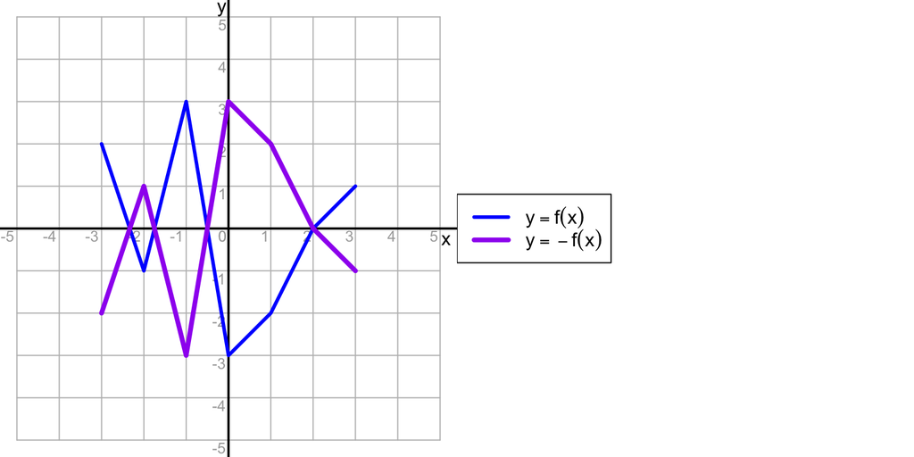

# Generate $-f(-x)$ from $f(x)$ table

Again, let’s reuse the example function:

| $x$ | $f(x)$ |
| --- | --- |
| -3 | 2 |
| -2 | -1 |
| -1 | 3 |
| 0 | -3 |
| 1 | -2 |
| 2 | 0 |
| 3 | 1 |

Our goal is to make another column for $-f(-x)$. Based on the two previous examples, you might be able to predict how to fill the $-f(-x)$ column.

- Pick a value of $x$. Let’s start with $x=-3$. Our goal is to evaluate $-f(-(-3))$.
- Simplify the expression inside the argument. We know $-(-3)=3$.
- So, we need to evaluate $-f(3)$.
- Okay, we can find $f(3)$ and then negate it.
- Thus, since $f(3)=1$, we know that $-f(-(-3))=-1$.

  | $x$ | $f(x)$ | $-f(-x)$ |
  | --- | --- | --- |
  | -3 | 2 | -1 |
  | -2 | -1 |  |
  | -1 | 3 |  |
  | 0 | -3 |  |
  | 1 | -2 |  |
  | 2 | 0 |  |
  | 3 | 1 |  |

- Can you predict how to fill the rest of the table?
- Basically, you can reverse the order of the second column and then negate each element.

  | $x$ | $f(x)$ | $-f(-x)$ |
  | --- | --- | --- |
  | -3 | 2 | -1 |
  | -2 | -1 | 0 |
  | -1 | 3 | 2 |
  | 0 | -3 | 3 |
  | 1 | -2 | -3 |
  | 2 | 0 | 1 |
  | 3 | 1 | -2 |

- Can you predict the geometric transformation that relates the graphs of $y=f(x)$ and $y=-f(-x)$?
- The two graphs are related by a 180° rotation around the origin.
- This is equivalent to combining two reflections, one over the $y$ axis and one over the $x$ axis (in either order).

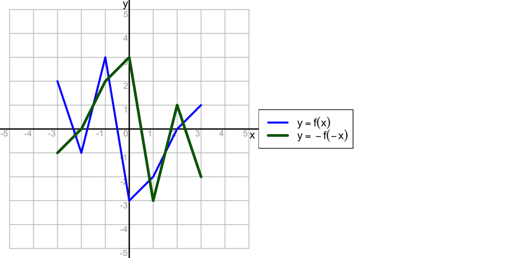

# All of them: $f(x)$ and $-f(x)$ and $f(-x)$ and $-f(-x)$

All four in a table:

| $x$ | $f(x)$ | $-f(x)$ | $f(-x)$ | $-f(-x)$ |
| --- | --- | --- | --- | --- |
| -3 | 2 | -2 | 1 | -1 |
| -2 | -1 | 1 | 0 | 0 |
| -1 | 3 | -3 | -2 | 2 |
| 0 | -3 | 3 | -3 | 3 |
| 1 | -2 | 2 | 3 | -3 |
| 2 | 0 | 0 | -1 | 1 |
| 3 | 1 | -1 | 2 | -2 |

All four graphed:

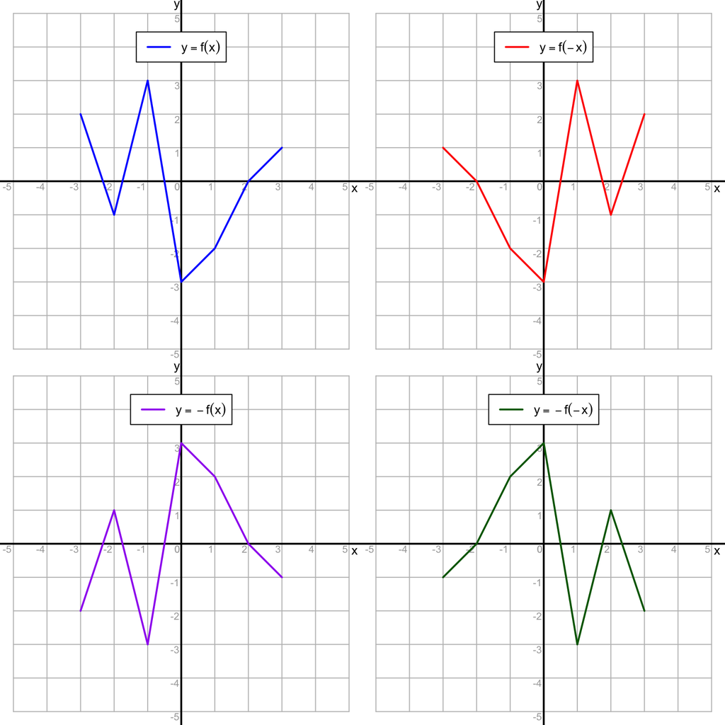

# Summary

- Graphs of $y=f(x)$ and $y=f(-x)$ are reflections over the $y$-axis. (So the corresponding $x$ values are opposites.)
  - For example if point $(3,1)$ is on $y=f(x)$ then point $(-3,1)$ is on $y=f(-x)$.
- Graphs of $y=f(x)$ and $y=-f(x)$ are reflections over the $x$-axis. (So the corresponding $y$ values are opposites.)
  - For example if point $(3,1)$ is on $y=f(x)$ then point $(3,-1)$ is on $y=-f(x)$.
- Graphs of $y=f(x)$ and $y=-f(-x)$ are reflections over both axes. In other words, they are 180° rotations around the origin. (So the corresponding $x$ values are opposites, and the corresponding $y$ values are opposites.)
  - For example if point $(3,1)$ is on $y=f(x)$ then point $(-3,-1)$ is on $y=-f(-x)$.

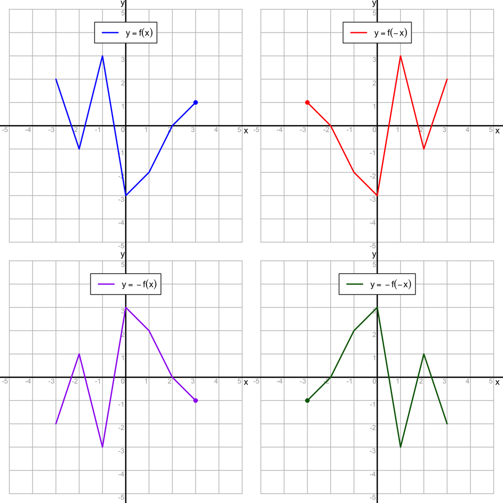